# 59 years of NFL field goal attempts - Exploring the data

James R Bland (https://sites.google.com/site/jamesbland/)

Novembe 18, 2019

A bit over a week ago I [sourced some advice from the twitter hive mind](https://twitter.com/JamesBland_Econ/status/1192519670009434114) about how to do a web scrape in R. This is new to me, so it was a good learning experience, and I’m sure it will take me 99% less time next time I want to do it. Thanks!

The aim was to download every NFL field goal attempt from [pro-football-reference.com](https://www.pro-football-reference.com/play-index/fg_finder.cgi). The problems were that (1) the site only displayed 500 attempts at a time (there are over 50,000 attempts in total), and that (2) the table is actually commented out in the html source, so it needed a bit of manipulation. Here is my mishmash of a solution based on the very helpful advice provided on Twitter:

```r
#FieldGoals_Scrape.R

rm(list=ls())
setwd("C:/Users/jbland/OneDrive - University of Toledo/General notes on structural Bayes/Sports")
#library(foreign)
#library(xtable)
#library(ggplot2)
#library(gganimate)
#library(gifski)
#library(png)
#library(rvest)
library(downloader)
#library(qdapRegex)
#library(readtext)
library(stringr)
#library(readr)
library(htmltab)
library(R.utils)

library(RCurl)



Data<-data.frame()

TeamList<-c("crd","atl","rav","buf","car","chi","cin","cle","dal","den","det","gnb","htx","clt","jax","kan","sdg","ram","mia","min","nwe","nor","nyg","nyj","rai","phi","pit","sfo","sea","tam","oti","was")

#TeamList<-c("rav")

for (yy in 1960:2019) {
for (tt in 1:length(TeamList)) {
  url<-paste("https://www.pro-football-reference.com/play-index/fg_finder.cgi?request=1&year_min=",yy,"&year_max=",yy,"&team_id=",TeamList[tt],"&game_type=E&game_num_min=0&game_num_max=99&week_num_min=0&week_num_max=99&min_distance=7&max_distance=80&order_by=game_date",sep="")
  filename<-"tempFieldGoalsScrape.html"
  download(url,filename)
  tx<-readLines(filename)
  if (sum(str_detect(tx,"Sorry, this search returns no results"))==0) { # some teams didn't exist in 1960


    tx2<-gsub(pattern = "<!--", replace = "", x = tx)
    tx3<-gsub(pattern = "-->", replace = "", x = tx2)
    #print(htmltab(tx3,which=2))
    D<-data.frame(htmltab(tx3,which=2))
    D<-D[,!names(D) %in% "V1"]
    Data<-rbind(Data,D)
  }
  print(paste(yy,TeamList[tt]))
}
}

write.csv(Data,"FieldGoalsDataScrape.csv")
```

This gets the job done, but I’m not fooling myself into thinking it is the world’s most elegant code. Anyway, this is what the data look like, and I will do something with it in Stan some time soon. Watch this space!

```r
head(Data)
```

```
##   X Rk       Date  Tm Opp  Result      Player Dist Good. Blk. Y B year
## 1 2  1 1960-12-18 STL PIT  W 38-7 Gerry Perry   16     Y    N 1 0 1960
## 2 3  2 1960-12-04 STL PHI  L 6-20 Gerry Perry   47     N    N 0 0 1960
## 3 4  3 1960-11-27 STL CLE T 17-17 Gerry Perry   23     Y    N 1 0 1960
## 4 5  4 1960-11-20 STL WAS W 26-14 Gerry Perry   18     N    N 0 0 1960
## 5 6  5 1960-11-20 STL WAS W 26-14 Gerry Perry   30     N    N 0 0 1960
## 6 7  6 1960-11-20 STL WAS W 26-14 Gerry Perry   27     Y    N 1 0 1960
##   month season
## 1    12   1960
## 2    12   1960
## 3    11   1960
## 4    11   1960
## 5    11   1960
## 6    11   1960
```

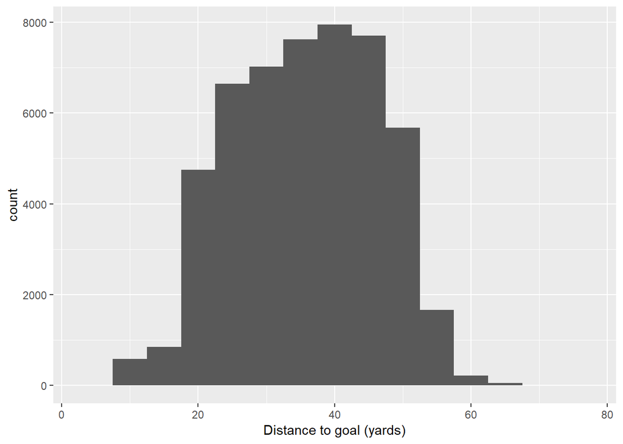

```r
plt<-ggplot(Data,aes(x=Dist))+geom_histogram(binwidth=5)+xlab("Distance to goal (yards)")
plt
```

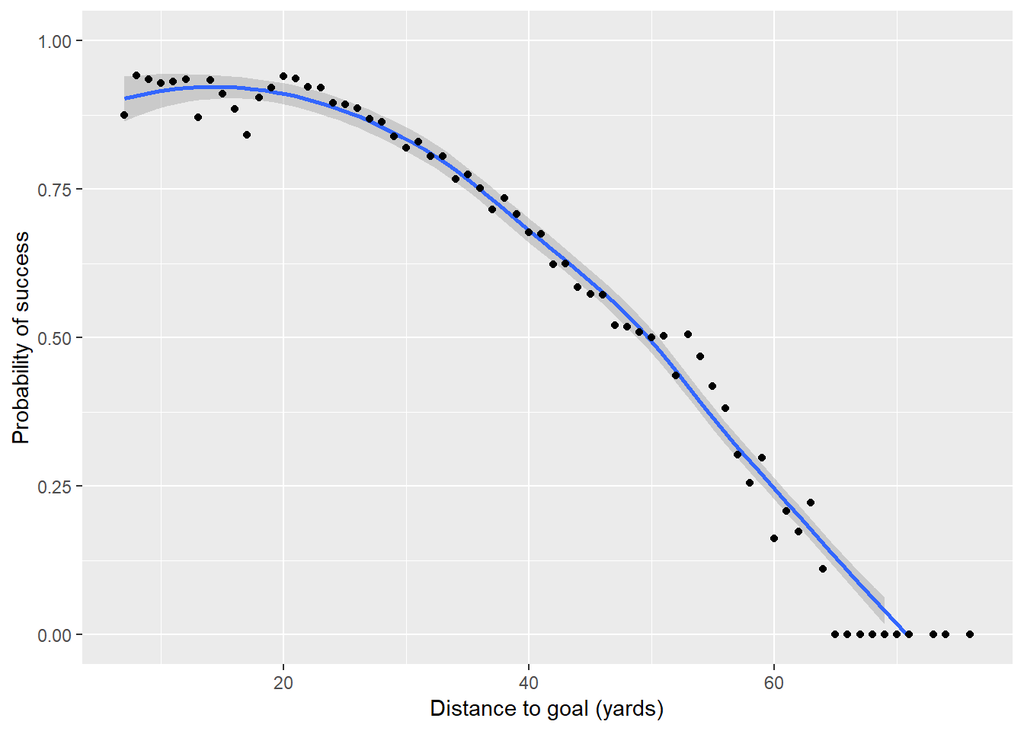

```r
AggData<-aggregate(Data[,c("Dist","Y","B")], by=list(Data$Dist),FUN=mean)
plt<-ggplot(AggData,aes(x=Dist,y=Y))+geom_smooth(method="loess")+xlab("Distance to goal (yards)")+ylab("Probability of success")+geom_point()+ylim(0,1)
plt
```

[See more coding examples here](https://sites.google.com/site/jamesbland/code-examples)